# Multilevel Modelling - Practical 4 (Week 5)

## Instructions – start here!

In this lab we will analyse the ``Active Time’’ data set considered at the end of the Lecture 5 slides. This lab is a little shorter than previous labs to allow time to understand the 3-level structure of the data and appropriate models.

We initially load the packages we need.

```r
require(lme4)
require(lmerTest)
require(ggplot2)
```

## Exercise 1: Analysis of the Active Time study data (lecture 5)

Read in the data as follows.

```r
Sim3level <-
  read.csv("https://andygolightly.github.io/teaching/MATH43515/Sim3level.csv")
```

Visually inspect the data frame.

```r
head(Sim3level)
```

|  | Math | ActiveTime | ClassSize | Classroom | School | StudentID |
| --- | --- | --- | --- | --- | --- | --- |
| 1 | 55.42604 | 0.06913359 | 18 | 1 | Sch1 | 1 |
| 2 | 54.34306 | 0.08462063 | 18 | 1 | Sch1 | 2 |
| 3 | 61.42570 | 0.12994557 | 18 | 1 | Sch1 | 3 |
| 4 | 56.12271 | 0.74613202 | 18 | 1 | Sch1 | 4 |
| 5 | 53.34900 | 0.03887918 | 18 | 1 | Sch1 | 5 |
| 6 | 57.99773 | 0.68563542 | 18 | 1 | Sch1 | 6 |

We have the following variables:

- `Math` maths score on $(0,100)$ (**response variable**)
- `ActiveTime` a standardised (to $(0,1)$) measure of the duration spent on actively interacting with learning materials (**covariate**)
- `ClassSize` the size of a given class (**covariate**)
- `Classroom` Class identifier
- `School` School identifier
- `StudentID` student identifier

We have a 3-level structure with students nested in classes in schools. Plainly, we have `ActiveTime` at the student level and `ClassSize` at the class level.

We can see the number of schools, classrooms within each school and number of students in each class via

```r
tapply(Sim3level$Classroom,Sim3level$School,table)
```

```
## $Sch1
##
##  1  2  3  4  5  6  7  8  9 10
## 18 14 20 14 15 18 20 16 12 14
##
## $Sch2
##
##  1  2  3  4  5  6  7  8
## 18 18 15 21 18 20 20 18
##
## $Sch3
##
##  1  2  3  4  5  6  7  8  9 10 11 12
## 19 24 20 24 23 20 24 20 19 23 24 21
```

For example, school 1 has 10 classes, with student numbers ranging from 12 to 20.

$~$

### How important is group structure? (VPCs and ICCs)

Let $y_{ijk}$ denote the response `maths` for student $i$ in class $j$ in school $k$. The random intercept only (empty) model is:

$$y_{ijk} = \gamma_0
+u_{jk}+v_k+\epsilon_{ijk}$$
where $u_{jk}\sim N(0,\sigma^2_u)$ is the random effect for classroom, $v_k\sim N(0,\sigma^2_v)$ is the random effect for school and $\epsilon_{ijk}\sim N(0,\sigma^2)$ is the usual error term. All random variables here are assumed independent.

$~$

We fit and summarise the random intercept only (empty model) via:

```r
Model.0 <- lmer(Math ~ 1
                 +(1|School)
                 +(1|School:Classroom),
                 data=Sim3level)
summary(Model.0)
```

```
## Linear mixed model fit by REML. t-tests use Satterthwaite's method [
## lmerModLmerTest]
## Formula: Math ~ 1 + (1 | School) + (1 | School:Classroom)
##    Data: Sim3level
##
## REML criterion at convergence: 3776.7
##
## Scaled residuals:
##     Min      1Q  Median      3Q     Max
## -3.5226 -0.6752  0.0000  0.6549  2.7502
##
## Random effects:
##  Groups           Name        Variance Std.Dev.
##  School:Classroom (Intercept) 44.93    6.703
##  School           (Intercept) 91.85    9.584
##  Residual                     37.22    6.101
## Number of obs: 570, groups:  School:Classroom, 30; School, 3
##
## Fixed effects:
##             Estimate Std. Error     df t value Pr(>|t|)
## (Intercept)   44.420      5.677  2.016   7.825   0.0156 *
## ---
## Signif. codes:  0 '***' 0.001 '**' 0.01 '*' 0.05 '.' 0.1 ' ' 1
```

We can then extract the estimated variance components from the model via:

```r
REsummary <- as.data.frame(VarCorr(Model.0))
REsummary
```

| grp | var1 | var2 | vcov | sdcor |
| --- | --- | --- | --- | --- |
| School:Classroom | (Intercept) | NA | 44.93358 | 6.703252 |
| School | (Intercept) | NA | 91.85144 | 9.583915 |
| Residual | NA | NA | 37.21794 | 6.100651 |

(*Note*: Alternatively you could use `summary(Model.0)$varcor`.)

**TASK:** Find and interpret all VPC and ICC values.

**Click for solution**

VPC estimates

```r
sig <- REsummary$vcov[3]  #Residual variance
sigv <- REsummary$vcov[2] #RE variance for school
sigu <- REsummary$vcov[1] #RE variance for class
totalvar <- sum(REsummary$vcov) #total variance
vpc.school <- sigv/totalvar

vpc.class <- sigu/totalvar
vpc.school
```

```
## [1] 0.5278728
```

```r
vpc.class
```

```
## [1] 0.2582346
```

ICC estimates

```r
icc.school <- sigv/totalvar

icc.class <- (sigu+sigv)/totalvar

icc.school
```

```
## [1] 0.5278728
```

```r
icc.class
```

```
## [1] 0.7861074
```

We have 26% response variation at the class level and 53% at the school level. Variability between schools is more than between classes. The ICC for class is 79% i.e. very large! Recall that this gives the correlation between two students in the same classroom in the same school. This correlation is largely “driven” by the school level ICC (53%) which is the correlation between two students in the same school but different classrooms.

$~$

### Three level Model with explanatory variables

The random intercept model with covariates for `ActiveTime` and `ClassSize` is given by

$$y_{ijk}=a+b_{1}\text{ActiveTime}_{ijk}+b_2\text{ClassSize}_{jk}+u_{jk}+v_{k}+\epsilon_{ijk}$$

We fit this model with the code:

```r
Model.1 <- lmer(Math ~ ActiveTime+ClassSize
                 +(1|School)
                 +(1|School:Classroom),
                 data=Sim3level)
summary(Model.1)
```

```
## Linear mixed model fit by REML. t-tests use Satterthwaite's method [
## lmerModLmerTest]
## Formula: Math ~ ActiveTime + ClassSize + (1 | School) + (1 | School:Classroom)
##    Data: Sim3level
##
## REML criterion at convergence: 3367.1
##
## Scaled residuals:
##     Min      1Q  Median      3Q     Max
## -3.3086 -0.6518 -0.0488  0.6330  3.0744
##
## Random effects:
##  Groups           Name        Variance Std.Dev.
##  School:Classroom (Intercept) 46.55    6.823
##  School           (Intercept) 83.98    9.164
##  Residual                     17.54    4.188
## Number of obs: 570, groups:  School:Classroom, 30; School, 3
##
## Fixed effects:
##             Estimate Std. Error       df t value Pr(>|t|)
## (Intercept)  41.1849    11.9131  17.8660   3.457  0.00284 **
## ActiveTime   14.9476     0.6066 539.8898  24.643  < 2e-16 ***
## ClassSize    -0.2110     0.5634  27.9933  -0.374  0.71089
## ---
## Signif. codes:  0 '***' 0.001 '**' 0.01 '*' 0.05 '.' 0.1 ' ' 1
##
## Correlation of Fixed Effects:
##            (Intr) ActvTm
## ActiveTime -0.030
## ClassSize  -0.889  0.007
```

Note that the above can be equivalently executed via

```r
Model.1 <- lmer(Math ~ ActiveTime+ClassSize
                 +(1|School/Classroom),
                 data=Sim3level)
```

### Comparison of empty model with model with explanatory variables

To test the null hypothesis that $b_1=0$ and $b_{2}=0$ against an alternative that at least one of these fixed effects is not 0, we can use

```r
anova(Model.0, Model.1)
```

```
## refitting model(s) with ML (instead of REML)
```

|  | npar | AIC | BIC | logLik | -2*log(L) | Chisq | Df | Pr(>Chisq) |
| --- | --- | --- | --- | --- | --- | --- | --- | --- |
| Model.0 | 4 | 3789.815 | 3807.197 | -1890.907 | 3781.815 | NA | NA | NA |
| Model.1 | 6 | 3385.603 | 3411.677 | -1686.802 | 3373.603 | 408.2115 | 2 | 2.280289e-89 |

Plainly, the null hypothesis is rejected, suggesting that explanatory variables are needed.

(*Technical note*: the above is actually giving the p-value for a likelihood ratio test (LRT) rather than an F-test, which is usually fine, provided we have sufficiently many data points informing the fixed effect(s) being tested.)

Note that the above output gives **AIC** (Akaike information criterion) and **BIC** (Bayesian information criterion). AIC is
$$\text{AIC}= 2p -2\ln
\hat{L}$$
where $\ln\hat{L}$ is the maximised log-likelihood and $p$ is the number of parameters. Given a set of candidate models for the data, the preferred model is the one with the smallest AIC value. Hence, AIC rewards goodness of fit (as assessed by the likelihood function), but also includes a penalty ($2p$). The penalty discourages overfitting, which is desired as increasing the number of parameters in the model almost always improves the goodness of the fit.

Similarly we have BIC as

$$\text{BIC}=p\ln n - 2\ln\hat{L}$$
where $n$ is the number of data points. As with AIC, when picking from several models, those with lower BIC values are generally preferred. Note that BIC penalises the number of parameters more strongly than AIC. From the above table, `model.1` is clearly preferred in terms of AIC and BIC.

### Further analysis (bottom up approach)

**TASK:** How does the model without the `ClassSize` covariate (call it `Model.2`) compare to `Model.1`? This question is really asking how the deviance changes from `Model.1` to `Model.2`. We know that the simpler `Model.2` will have a bigger deviance than `Model.1`. BUT, if this difference is very small, we should prefer the simpler model. Test this hypothesis formally using the `anova()` function (after first creating `Model.2` using `lmer()`). Does AIC and BIC confirm your finding?

**Click for solution**

Remove `ClassSize` and refit:

```r
Model.2 <- lmer(Math ~ ActiveTime
                 +(1|School/Classroom),
                 data=Sim3level)
summary(Model.2)
```

```
## Linear mixed model fit by REML. t-tests use Satterthwaite's method [
## lmerModLmerTest]
## Formula: Math ~ ActiveTime + (1 | School/Classroom)
##    Data: Sim3level
##
## REML criterion at convergence: 3367.9
##
## Scaled residuals:
##     Min      1Q  Median      3Q     Max
## -3.3082 -0.6504 -0.0510  0.6339  3.0697
##
## Random effects:
##  Groups           Name        Variance Std.Dev.
##  Classroom:School (Intercept) 44.71    6.686
##  School           (Intercept) 92.65    9.626
##  Residual                     17.54    4.188
## Number of obs: 570, groups:  Classroom:School, 30; School, 3
##
## Fixed effects:
##             Estimate Std. Error       df t value Pr(>|t|)
## (Intercept)  37.2207     5.7037   2.0272   6.526   0.0219 *
## ActiveTime   14.9492     0.6065 539.9821  24.647   <2e-16 ***
## ---
## Signif. codes:  0 '***' 0.001 '**' 0.01 '*' 0.05 '.' 0.1 ' ' 1
##
## Correlation of Fixed Effects:
##            (Intr)
## ActiveTime -0.051
```

Now compare models with and without the `ClassSize` fixed effect:

```r
anova(Model.2, Model.1)
```

```
## refitting model(s) with ML (instead of REML)
```

|  | npar | AIC | BIC | logLik | -2*log(L) | Chisq | Df | Pr(>Chisq) |
| --- | --- | --- | --- | --- | --- | --- | --- | --- |
| Model.2 | 5 | 3383.882 | 3405.611 | -1686.941 | 3373.882 | NA | NA | NA |
| Model.1 | 6 | 3385.603 | 3411.677 | -1686.802 | 3373.603 | 0.278994 | 1 | 0.5973614 |

The change in deviance is tiny! We have insufficient evidence against the null hypothesis that the fixed effect for `ClassSize` is zero. We therefore retain the null and conclude that `ClassSize` is not needed. AIC and BIC agree with this finding.

$~$

**TASK:** Is a random slope needed (allowing a different slope for `ActiveTime` in each class)? Create `Model.3` using `lmer()` with the inclusion of a random slope for `ActiveTime`. Test the null hypothesis that the random slope variance is zero using `ranova(Model.3)`.

**Click for solution**

Now let’s add a random slope for `ActiveTime`:

```r
Model.3 <- lmer(Math ~ ActiveTime
                 +(1|School)
                 +(1+ActiveTime|School:Classroom),
                 data=Sim3level)
```

Now test to see if the random slope variance can be assumed zero or not:

```r
ranova(Model.3)
```

|  | npar | logLik | AIC | LRT | Df | Pr(>Chisq) |
| --- | --- | --- | --- | --- | --- | --- |
|  | 7 | -1666.007 | 3346.015 | NA | NA | NA |
| (1 \| School) | 6 | -1674.685 | 3361.370 | 17.35490 | 1 | 3.100973e-05 |
| ActiveTime in (1 + ActiveTime \| School:Classroom) | 5 | -1683.971 | 3377.942 | 35.92764 | 2 | 1.579109e-08 |

which suggests that the random slope is needed.

$~$

**TASK:** Is the resulting model a good fit (check diagnostics)? Try `plot(Model.3)` then use `resid()` and `ranef()` to get estimated residuals and random effects. For the latter, note that a list will be returned, with the first list item holding the estimated intercepts and slopes the class level, and the second list item holding the estimated intercepts at the school level.

**Click for solution**

Diagnostics:

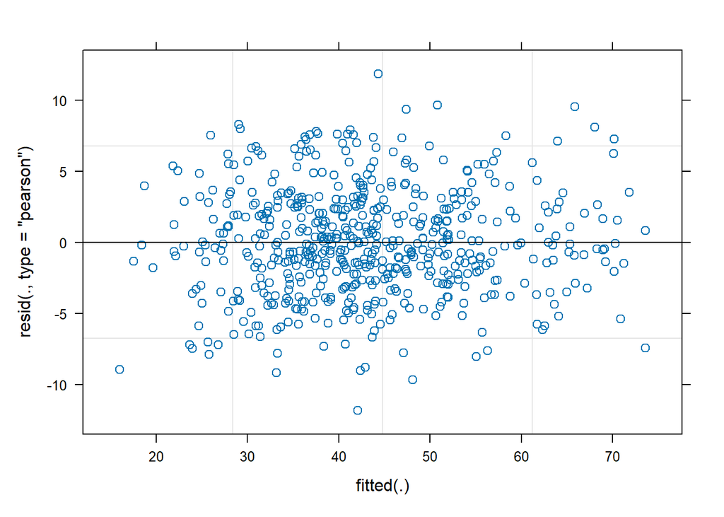

```r
plot(Model.3)
```

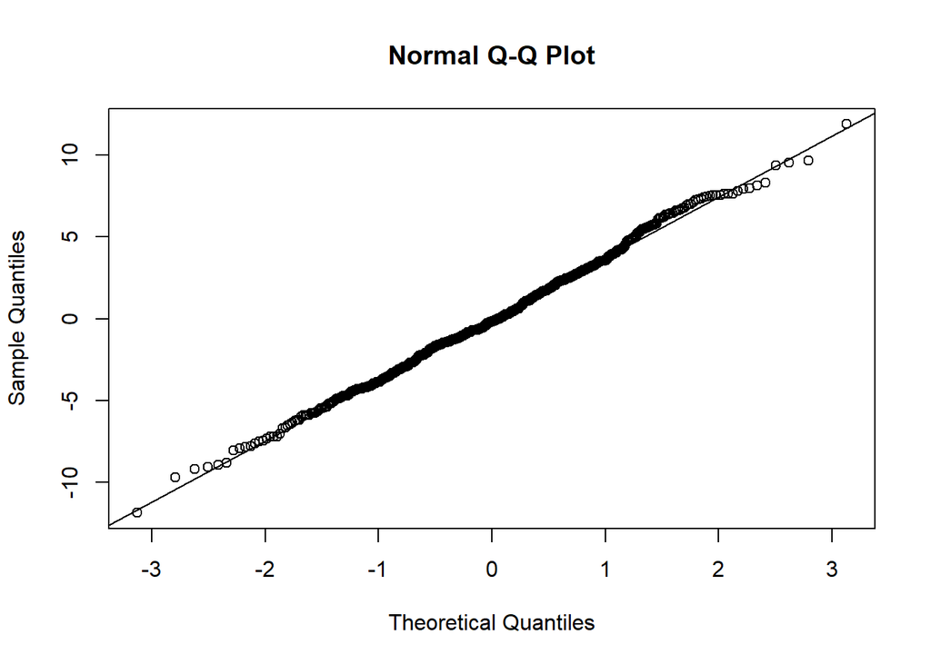

```r
qqnorm(resid(Model.3))
qqline(resid(Model.3))
```

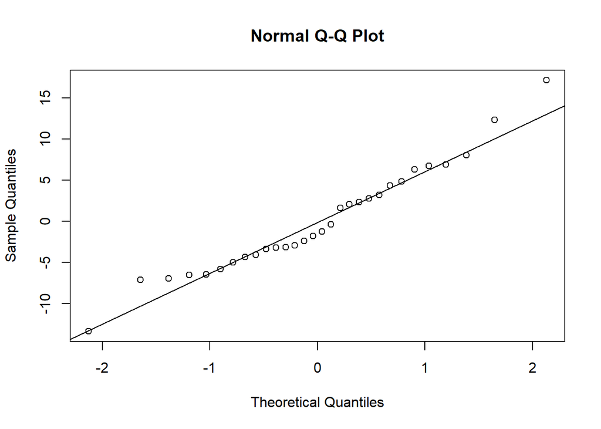

```r
qqnorm(ranef(Model.3)[[1]][,1])
qqline(ranef(Model.3)[[1]][,1])
```

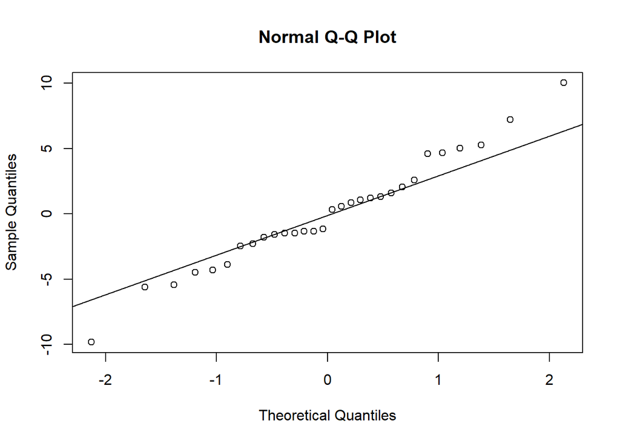

```r
qqnorm(ranef(Model.3)[[1]][,2])
qqline(ranef(Model.3)[[1]][,2])
```

```r
#qqnorm(ranef(Model.3)[[2]][,1])
#qqline(ranef(Model.3)[[2]][,1]) #Omit as only 3 schools!
```

I think the fit looks reasonable - why?

$~$

**TASK (harder):** How can we visualise the fit of `Model.3`? Recall the `predict` function and use `ggplot()` to produce a graph showing fitted lines for all classrooms in school 1. Hint: `Sim3level[Sim3level$School=="Sch1",]` will give the part of the data set for school 1.

**Click for solution**

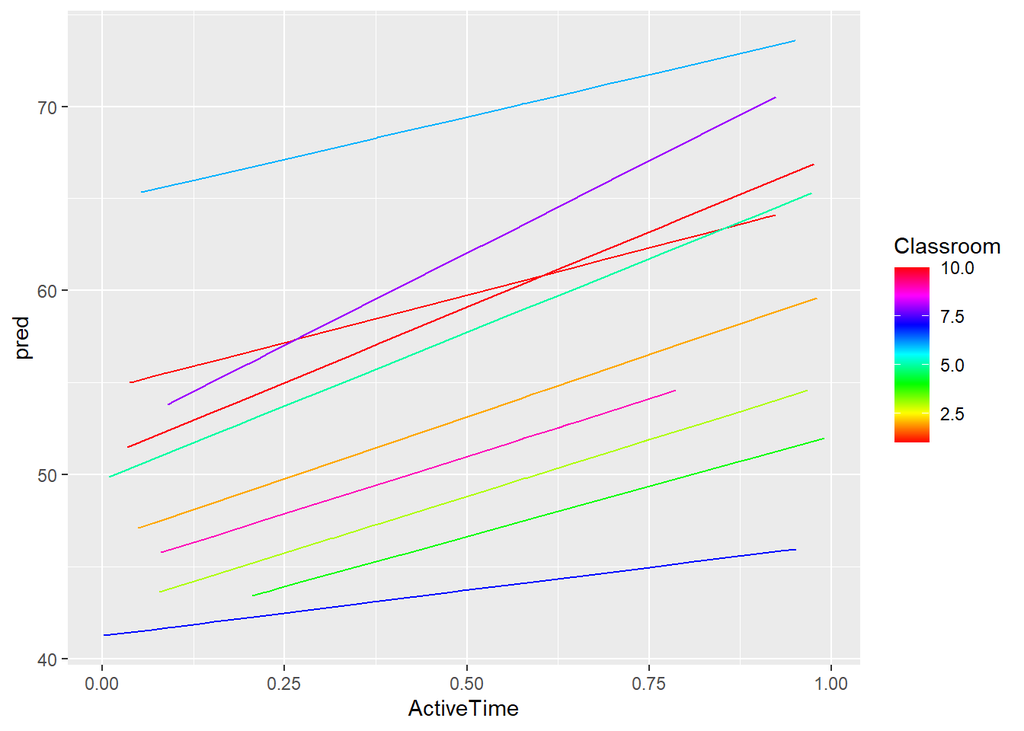

```r
Sim3level$pred <- predict(Model.3)
ggplot(Sim3level[Sim3level$School=="Sch1",],
       aes(x=ActiveTime,y=Math,col=Classroom,group=Classroom))+
  geom_line(aes(y=pred))+
  scale_color_gradientn(colours=rainbow(100))
```

$~$

**Understanding the model**: `Model.3` can be written mathematically as

$$y_{ijk}=a+b\text{ActiveTime}_{ijk}+w_{jk}\text{ActiveTime}_{ijk}+u_{jk}+v_{k}+\epsilon_{ijk}$$
with $w_{jk}\sim N(0,\sigma^2_w)$ representing the random slopes (we get a different one for each classroom and school combination). We can visualise the fitted model in all 3 schools:

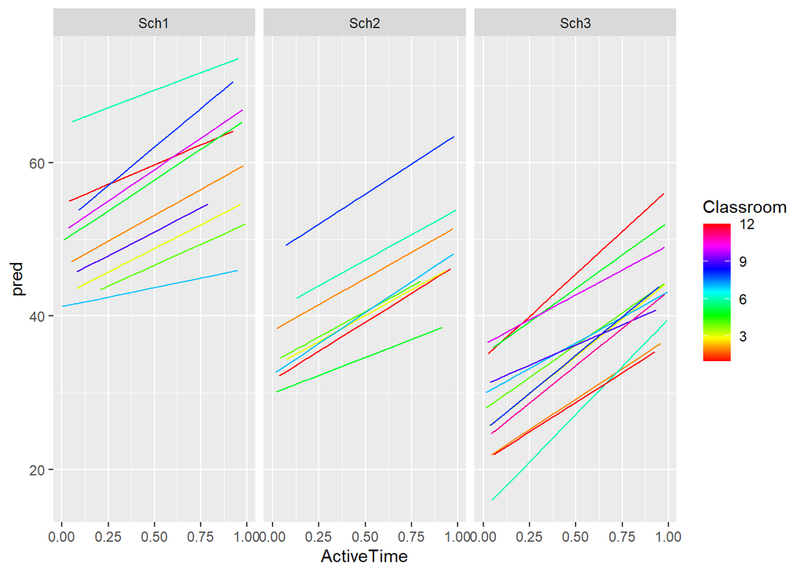

**Click for the code to see the above**

```r
Sim3level$pred <- predict(Model.3)
ggplot(Sim3level,
       aes(x=ActiveTime,y=Math,col=Classroom,group=Classroom))+
  facet_wrap(~School)+
  geom_line(aes(y=pred))+
  scale_color_gradientn(colours=rainbow(100))
```

One may expect differences between classes if students are streamed by ability or if they correspond to different age groups. The effect of `ActiveTime` on maths scores appears similar across the different schools, but scores seem much lower in School 3.

The plots above also make clear the role of the random intercept and slope terms at the classroom level; the fitted line for each classroom $j$ within a school $k$ has its own intercept $a+u_{jk}+v_{k}$ and slope $b+w_{jk}$. Hence, $a$ gives the average intercept value, the $v_{k}$ term allows for differences in intercept values between schools and the $u_{jk}$ allows for further intercept differences between classrooms within schools. Similary, the random slope $w_{jk}$ allows for a different linear relationship between the response and covariate for each classroom-school combination.

What else can you say that is interesting?

- Try interpreting the effect of $\text{ActiveTime}$ on the expected response.
- Look at the correlation between the $u_{jk}$ and $w_{jk}$ (from the model summary). Does it make sense in light of the plot above?
- We could try including a random slope on $\text{ActiveTime}$ at the school level. This will more than likely give a “boundary (singular) fit” warning, which usually indicates over-fitting. This can happen if there are too few observations to reliably estimate the parameters at a particular level (and note that we only have 3 schools here). In this case, reducing the complexity of the model (by removing the higher level random slope) is recommended.

## Exercise 3: formative assignment

If time permits, you may wish to work on the formative assignment. Don’t forget to look at the notes on model building from this week’s tutorial!

$~$

End of lab!